# Supplementary Information S1. In: Mediterranean seasonality overrides the effect of the halophyte Arthrocnenum macrostachyum in determining the bacterial community in saline soils

Miguel Camacho-Sánchez

10/4/2018

## 1. Trimming of sequences

Cutadapt 1.8.3 was used to trim F341 (CCTACGGGNGGCWGCAG) and R785 (GACTACHVGGGTATCTAATCC) primers (Klindworth et al. 2013) from R1 and R2 reads respectively. List all files in directory `ls`:

```
## L1-1_S195_R1.fastq
## L1-1_S195_R2.fastq
## L1-2_S210_R1.fastq
## L1-2_S210_R2.fastq
## L1-2a_S211_R1.fastq
## L1-2a_S211_R2.fastq
## L1-3a_S194_R1.fastq
## L1-3a_S194_R2.fastq
## L1-4_S197_R1.fastq
## L1-4_S197_R2.fastq
## L2-1_S206_R1.fastq
## L2-1_S206_R2.fastq
## L2-2_S207_R1.fastq
## L2-2_S207_R2.fastq
## L2-3-rep_S212_R1.fastq
## L2-3-rep_S212_R2.fastq
## L2-3_S208_R1.fastq
## L2-3_S208_R2.fastq
## L2-4_S209_R1.fastq
## L2-4_S209_R2.fastq
## negativo_S215_R1.fastq
## negativo_S215_R2.fastq
```

Run loop to (1) trim forward primer anchored to 5’ end in R1 reads and reverse primer anchored to 5’ end in R2 reads, and (2) write to ouput with only paired sequences for which both primers were found:

```bash
fastq1=($(find *1.fastq))
fastq2=($(find *2.fastq))
long=($(echo ${#fastq1[@]}))
for i in `seq 0 $((long-1))`
do
cutadapt -g ^CCTACGGGNGGCWGCAG -G ^GACTACHVGGGTATCTAATCC --trimmed-only -o ${fastq1[i]%%.*}_cutadapt.fastq -p ${fastq2[i]%%.*}_cutadapt.fastq ${fastq1[i]} ${fastq2[i]}
done >cutadatp_filtering.txt
```

## 2. Determination of Amplicon Sequence Variants (ASVs)

We followed the strategy described in [Callahan et al. 2016](http://dx.doi.org/10.12688/f1000research.8986.2) in its latest [update](https://bioconductor.org/help/course-materials/2017/BioC2017/Day1/Workshops/Microbiome/MicrobiomeWorkflowII.html).

Load libraries into R:

```r
library("knitr")
#Start session
.cran_packages <- c("ggplot2", "gridExtra")
  #load libraries
.bioc_packages <- c("dada2", "phyloseq", "DECIPHER", "phangorn")
  # Load packages into session, and print package version
sapply(c(.cran_packages, .bioc_packages), require, character.only = TRUE)
```

```
##   ggplot2 gridExtra     dada2  phyloseq  DECIPHER  phangorn
##      TRUE      TRUE      TRUE      TRUE      TRUE      TRUE
```

Set `path` to path directory with trimmed sequences from cutadapt: `path<-"path_to_sequences"`

Store paths for sequences to be read and for filtered sequences:

```r
fnFs <- sort(list.files(path, pattern="_R1_cutadapt.fastq", full.names = TRUE))
fnRs <- sort(list.files(path, pattern="_R2_cutadapt.fastq", full.names = TRUE))
sample.names <- sapply(strsplit(basename(fnFs), "_"), `[`, 1)

#create path for sequences that will be filtered downstream
filt_path <- file.path(path, "filtered")
if(!file_test("-d", filt_path)) dir.create(filt_path)

filtFs <- file.path(filt_path, paste0(sample.names, "_F_filt.fastq.gz"))
filtRs <- file.path(filt_path, paste0(sample.names, "_R_filt.fastq.gz"))
```

Check quality plots for R1 and R2:

```r
qualplt<-plotQualityProfile(c(fnFs,fnRs),n=5000,aggregate=F)#for 5000 random reads
```

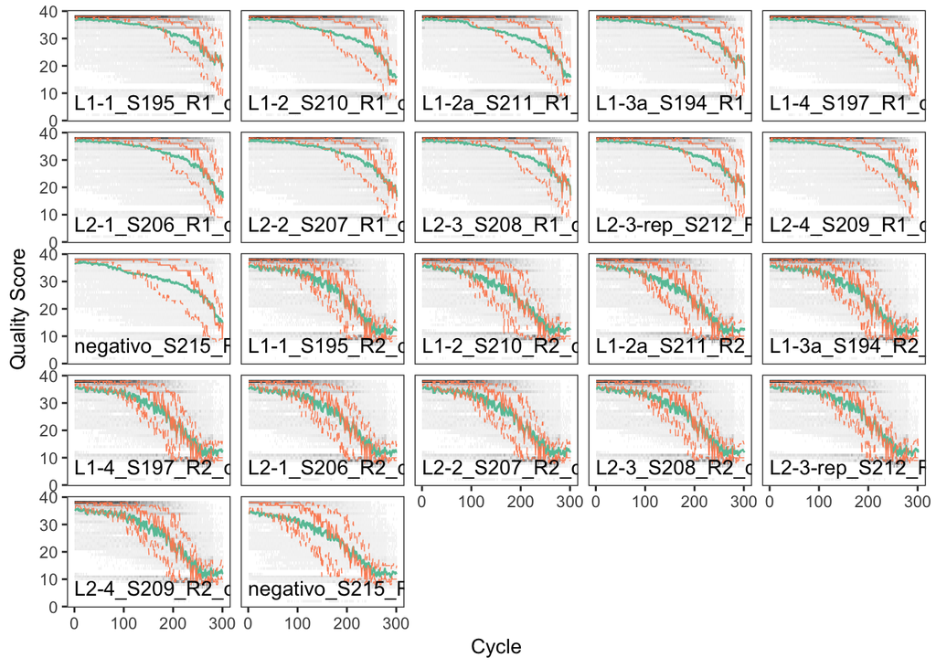

Figure S1.1. Quality plot

```r
qualplt
```

Based on the quality plots we decided to truncate R1 reads to 275 nt and R2 reads to 180 nt. Considering the amplicon length is ~425 nt (without primers), we would still have have ~30 nt of overlap for merging R1 and R2, downstream. Due to the lower quality of R2, we set less stringent parameters for expected maximum errors (maxEE=6).

```r
out <- filterAndTrim(fnFs, filtFs, fnRs, filtRs,maxN=0,maxEE=c(3,6), truncQ=2,compress=TRUE, multithread=TRUE,truncLen=c(275,180))
```

Around 75% of the paired reads passed the filter:

```r
cbind(out,"Retained"=out[,2]/out[,1])
```

```
##                                 reads.in reads.out  Retained
## L1-1_S195_R1_cutadapt.fastq       128084     96269 0.7516083
## L1-2_S210_R1_cutadapt.fastq       117941     81947 0.6948135
## L1-2a_S211_R1_cutadapt.fastq      216673    149995 0.6922644
## L1-3a_S194_R1_cutadapt.fastq      108028     81665 0.7559614
## L1-4_S197_R1_cutadapt.fastq       128643     97152 0.7552063
## L2-1_S206_R1_cutadapt.fastq       175392    131148 0.7477422
## L2-2_S207_R1_cutadapt.fastq       170613    127755 0.7487999
## L2-3_S208_R1_cutadapt.fastq       129206     98010 0.7585561
## L2-3-rep_S212_R1_cutadapt.fastq   210348    160402 0.7625554
## L2-4_S209_R1_cutadapt.fastq       113904     85848 0.7536873
## negativo_S215_R1_cutadapt.fastq     1632      1067 0.6537990
```

In dada2 the amount of computing power needed growths quadratically with sequencing depth, [big data](https://benjjneb.github.io/dada2/bigdata.html). For that reason, we decided to calculate the error matrices from a random subsample of 10,000 reads from each sample:

```r
library(ShortRead)
n=10000#seq to subsample
filtFs10000<-NA#empty vector to paste filepath for R1 reads
for(i in 1:length(filtFs)){#loop to subsample n seq
  sampler<-FastqSampler(filtFs[i],n)
  temp<- yield(sampler)
  pathx<-file.path(filt_path,paste0(sample.names[i],"_F_filt_10000_fastq.gz"))#name for new file
  writeFastq(temp,pathx)
  filtFs10000[i]<-pathx#filepath for newly created files
}
#the same loop for R2 reads
filtRs10000<-NA
for(i in 1:length(filtRs)){
  sampler<-FastqSampler(filtRs[i],n)
  temp<- yield(sampler)
  pathx<-file.path(filt_path,paste0(sample.names[i],"_R_filt_10000_fastq.gz"))
  writeFastq(temp,pathx)
  filtRs10000[i]<-pathx
}
```

Learn the error rates for R1 and R2 reads independently:

```r
errF <- learnErrors(filtFs10000, multithread=TRUE)
errR <- learnErrors(filtRs10000, multithread=TRUE)
```

Errors increase with low-quality:

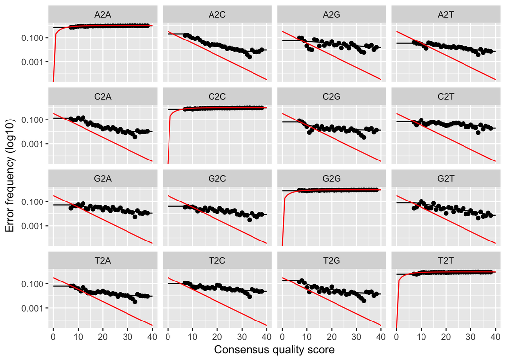

Figure S1.2. Error plots

```r
plotErrors(errF, nominalQ=TRUE)
```

Derreplication removes sequences which are the same thus lowering the computing burden for downstream analysis:

```r
derepFs <- derepFastq(filtFs, verbose=TRUE)
derepRs <- derepFastq(filtRs, verbose=TRUE)
# Name the derep-class objects by the sample names
names(derepFs) <- sample.names
names(derepRs) <- sample.names
```

Infer ASVs for each sample:

```r
dadaFs <- dada(derepFs, err=errF, multithread=TRUE)
dadaRs <- dada(derepRs, err=errR, multithread=TRUE)
```

Merge paired reads. Spurious sequence variants are further reduced by merging overlapping reads:

```r
mergers <- mergePairs(dadaFs, derepFs, dadaRs, derepRs, verbose=TRUE,minOverlap = 20,maxMismatch=0)
```

Construct sequence table (analogous to an OTU table) from the provided list of samples:

```r
seqtab <- makeSequenceTable(mergers)
```

Number of samples and variants:

```r
dim(seqtab)
```

```
## [1]    11 11572
```

Distribution of sequence lengths:

```r
table(nchar(getSequences(seqtab)))
```

```
##
##  275  324  342  344  374  385  387  390  396  398  400  401  402  403  404
##   18    1    1    2    3    1    6    2    1    4   12   75 1319  627  402
##  405  406  407  408  409  410  411  412  413  414  415  416  417  418  419
##  137   45  730   50   65   16   41   12    9   16   11   51   26   68   96
##  420  421  422  423  424  425  426  427  428  429  430  431
##  161  890 1045  112  226   39  770 2628 1477  355   21    1
```

Sequences that are much longer or shorter than expected may be the result of non-specific priming, and may be worth removing:

```r
seqtab2 <- seqtab[,nchar(colnames(seqtab)) %in% seq(387,431)]
```

Remove bimeras:

```r
seqtabNoC <- removeBimeraDenovo(seqtab2)
```

Proportion of sequences kept:

```r
seqkept<-sum(seqtabNoC)/sum(seqtab2)
```

Proportion of variants kept:

```r
varkept<-ncol(seqtabNoC)/ncol(seqtab2)
```

After removing bimeras 0.8984154 of the sequences were kept, which implied 0.5366361 of the variants.

### 2.1 Track reads through the pipeline

```r
getN <- function(x) sum(getUniques(x))
track <- cbind(out, sapply(dadaFs, getN), sapply(mergers, getN), rowSums(seqtab2), rowSums(seqtabNoC))
colnames(track) <- c("input", "filtered", "denoised", "merged", "tabled", "nonchim")
rownames(track) <- sample.names
```

```r
track
```

```
##           input filtered denoised merged tabled nonchim
## L1-1     128084    96269    96269  70387  70347   66417
## L1-2     117941    81947    81947  65206  65064   50255
## L1-2a    216673   149995   149995 122302 122145  111980
## L1-3a    108028    81665    81665  65625  65625   61976
## L1-4     128643    97152    97152  68485  68470   63647
## L2-1     175392   131148   131148  76438  76423   64853
## L2-2     170613   127755   127755  88642  88638   80707
## L2-3     129206    98010    98010  61220  61218   53266
## L2-3-rep 210348   160402   160402 113034 113029  101832
## L2-4     113904    85848    85848  61091  61086   56584
## negativo   1632     1067     1067    723    723     718
```

Variants per sample:

```r
apply(seqtabNoC,1,function(x){sum(x>0)})
```

```
##     L1-1     L1-2    L1-2a    L1-3a     L1-4     L2-1     L2-2     L2-3
##     1298      502      445     1427     1357     1110     1267      915
## L2-3-rep     L2-4 negativo
##     1537     1083       53
```

### 2.2 Assign taxonomy

Assign taxonomy with formatted [Silva v128 database](https://zenodo.org/record/801832#.WoVUHZOdW34):

```r
fastaRef <- file.path("path_to/silva_nr_v128_train_set.fa.gz")
taxTabSilva <- assignTaxonomy(seqtabNoC, refFasta = fastaRef, multithread=TRUE)#assigns taxonomy down to Genus
taxTabSilva_esp <- addSpecies(taxTabSilva, "path_to/silva_species_assignment_v128.fa.gz")#adds a Species column
```

### 2.3 Taxonomy filtering

Phyloseq package allows integrating taxonomy table, ASVs table, metadata, phylogenetic trees into an unique phyloseq object for further manipulation. Import metadata:

```r
meta<-read.csv("path_to/metadata.txt",colClasses=c("ID"="character"))
```

Do all samples in the ASV table (seqtabNoC) are present in the metadata?

```r
all(rownames(seqtabNoC) %in% meta$ID)
```

```
## [1] TRUE
```

```r
rownames(meta) <- meta$ID
```

Create phyloseq object:

```r
ps <- phyloseq(otu_table(seqtabNoC, taxa_are_rows=FALSE),
               sample_data(meta),
               tax_table(taxTabSilva_esp))
ps
```

```
## phyloseq-class experiment-level object
## otu_table()   OTU Table:         [ 6196 taxa and 11 samples ]
## sample_data() Sample Data:       [ 11 samples by 5 sample variables ]
## tax_table()   Taxonomy Table:    [ 6196 taxa by 7 taxonomic ranks ]
```

Show taxonomic ranks in the dataset:

```r
rank_names(ps)
```

```
## [1] "Kingdom" "Phylum"  "Class"   "Order"   "Family"  "Genus"   "Species"
```

ASVs per Kingdom and Phylum:

```r
table(tax_table(ps)[, "Kingdom"], exclude = NULL)
```

```
##
##  Archaea Bacteria
##        6     6190
```

```r
table(tax_table(ps)[, "Phylum"], exclude = NULL)
```

```
##
##        Acidobacteria       Actinobacteria      Armatimonadetes
##                  217                  857                   16
##        Bacteroidetes                 BRC1           Chlamydiae
##                  804                   32                   16
##             Chlorobi          Chloroflexi        Cyanobacteria
##                    7                  370                   67
##      Deferribacteres  Deinococcus-Thermus        Elusimicrobia
##                    2                   24                    7
##        Euryarchaeota                  FBP        Fibrobacteres
##                    6                    5                    6
##           Firmicutes         Fusobacteria     Gemmatimonadetes
##                  268                    5                  441
##      Gracilibacteria      Hydrogenedentes      Ignavibacteriae
##                    2                    9                   11
##      Latescibacteria        Lentisphaerae       Microgenomates
##                    9                    2                   12
##          Nitrospinae          Nitrospirae         Omnitrophica
##                    1                    8                    7
##        Parcubacteria              PAUC34f    Peregrinibacteria
##                   28                    1                    2
##       Planctomycetes       Proteobacteria RBG-1_(Zixibacteria)
##                  430                 2197                    6
##     Saccharibacteria              SBR1093         Spirochaetae
##                   86                    5                   20
##        Tectomicrobia          Tenericutes   TM6_(Dependentiae)
##                   10                    3                    5
##      Verrucomicrobia                  WS2                  WS6
##                  142                    3                   13
##                 <NA>
##                   34
```

Remove ASVs with NO Phylum assigned and only keep Kingdom Bacteria:

```r
ps <- subset_taxa(ps, !is.na(Phylum))
ps <- subset_taxa(ps, Kingdom=='Bacteria')
```

### 2.4 Negative control

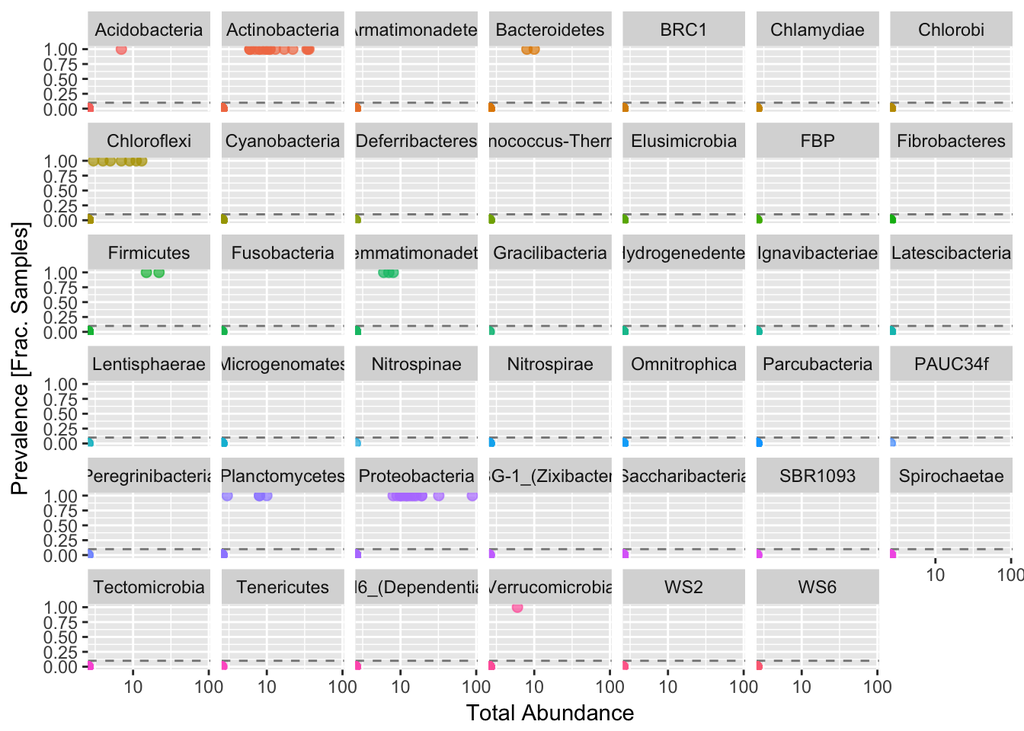

Figure S1.3. per-Phylum ASV prevalence for the negative control

```r
#Function to have a look at the abundance plots per phylum(also crates prevalence table [[1]],and plots[[3]])
plot_abundances<-function(phylo){
  prev = apply(X = otu_table(phylo),
               MARGIN = ifelse(taxa_are_rows(phylo), yes = 1, no = 2),
               FUN = function(x){sum(x > 0)})
  # Add taxonomy and total read counts to this data.frame
  prev = data.frame(Prevalence = prev,
                    TotalAbundance = taxa_sums(phylo),
                    tax_table(phylo))

  ##Get prevalence per phylum

  prevalence_per_phylum<-plyr::ddply(prev, "Phylum", function(df1){cbind(mean(df1$Prevalence),sum(df1$Prevalence))})

  ##Plot abundances vs prevalence

  plot1<-ggplot(prev, aes(TotalAbundance, Prevalence / nsamples(phylo),color=Phylum)) +
    # Include a guess for parameter
    geom_hline(yintercept = 0.1, alpha = 0.5, linetype = 2) +  geom_point(size = 2, alpha = 0.7) +
    scale_x_log10() +  xlab("Total Abundance") + ylab("Prevalence [Frac. Samples]") +
    facet_wrap(~Phylum) + theme(legend.position="none")
  return(list(prev,prevalence_per_phylum,plot1))
}

ps_neg<-prune_samples(sample.names=="negativo",ps)#create phyloseq object with the negative control
neg_summary<-plot_abundances(ps_neg)
neg_summary[[3]]
```

```r
ps<-prune_samples(sample_names(ps) != "negativo",ps)#remove negative sample from dataset
```

### 2.5 Abundance/prevalence filtering

Secondly, we set filters based on abundances and prevalence. We evaluated replicas to estimate abundance/prevalence thresholds for ASVs. Count in how many samples all given ASVs are present (prevalence) and plot in an histogram the abundance of ASVs with Prevalence = 1 vs 2.

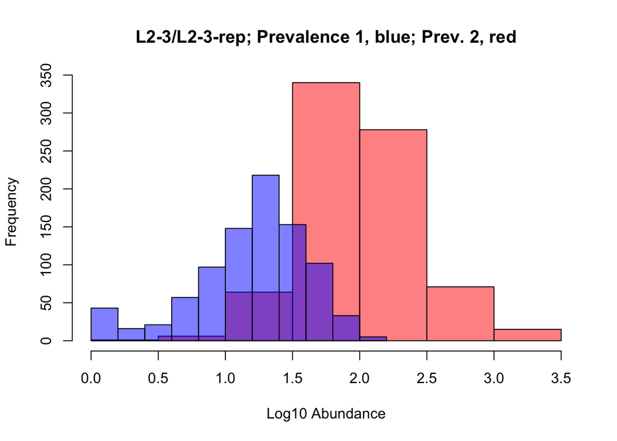

Figure S1.4. Shared vs non-shared ASV for replicas

```r
library(data.table)
ps_rep<-subset_samples(ps,ID %like% "L2-3")#keeps only samples L2-3 and L2-3rep.

prevdf_rep = apply(X = otu_table(ps_rep),#creates vector with prevalence
                MARGIN = ifelse(taxa_are_rows(ps_rep), yes = 1, no = 2),
                FUN = function(x){sum(x > 0)})
prevdf_rep = data.frame(Prevalence = prevdf_rep,#adds abundance and prevalence vector to data frame
                     TotalAbundance = taxa_sums(ps_rep),
                     tax_table(ps_rep))

# Histogram Grey Color
hist(log10(prevdf_rep$TotalAbundance[prevdf_rep$Prevalence=="2"]), col=rgb(1,0,0,0.5),main="L2-3/L2-3-rep; Prevalence 1, blue; Prev. 2, red",xlab="Log10 Abundance")#plot the abundance for varians with a prevalence of 2

hist(log10(prevdf_rep$TotalAbundance[prevdf_rep$Prevalence=="1"]), col=rgb(0,0,1,0.5), add=T)#plot the abundance for variants with a prevalence of 1
```

```r
rm(ps_rep)
rm(prevdf_rep)
```

The histograms seem to indicate that for ASVs with an abundance >100 (log10(100)=2), the chances of having variants only present in one of the replicas is very low.

```r
ps<-prune_samples(!(sample_names(ps) %in% c("L1-2","L2-3-rep")),ps)
ps
```

```
## phyloseq-class experiment-level object
## otu_table()   OTU Table:         [ 6156 taxa and 8 samples ]
## sample_data() Sample Data:       [ 8 samples by 5 sample variables ]
## tax_table()   Taxonomy Table:    [ 6156 taxa by 7 taxonomic ranks ]
```

Based on the histogram above we decided to remove all ASVs for which the product of the abundances for the samples in which they were present was below 100:

```r
prevdf = apply(X = otu_table(ps),#vector with prevalence
               MARGIN = ifelse(taxa_are_rows(ps), yes = 1, no = 2),
               FUN = function(x){sum(x > 0)})
mult = apply(X = otu_table(ps),#vector with product of all non-0 abundances
              MARGIN = ifelse(taxa_are_rows(ps), yes = 1, no = 2),
              FUN = function(x){prod(x[which(x > 0)])})
prevdf = data.frame(Prevalence = prevdf,#data frame with above information
                    TotalAbundance = taxa_sums(ps),
                    Product = mult,
                    tax_table(ps))

#Set abundance/prevalence threshold for filter:
prev_abundance_Threshold = 100#abundance threshold

#Execute filter:
keepTaxa = rownames(prevdf)[(prevdf$Product > prev_abundance_Threshold)]
ps_filt = prune_taxa(keepTaxa, ps)
```

### 2.6 Remove mitochondrial and chloroplastic variants:

```r
ps_filt <- subset_taxa(ps_filt, !Class %in% "Chloroplast" & !Family %in% "Mitochondria")
ps_filt
```

```
## phyloseq-class experiment-level object
## otu_table()   OTU Table:         [ 1944 taxa and 8 samples ]
## sample_data() Sample Data:       [ 8 samples by 5 sample variables ]
## tax_table()   Taxonomy Table:    [ 1944 taxa by 7 taxonomic ranks ]
```

Plot ASVs abundances per Phylum:

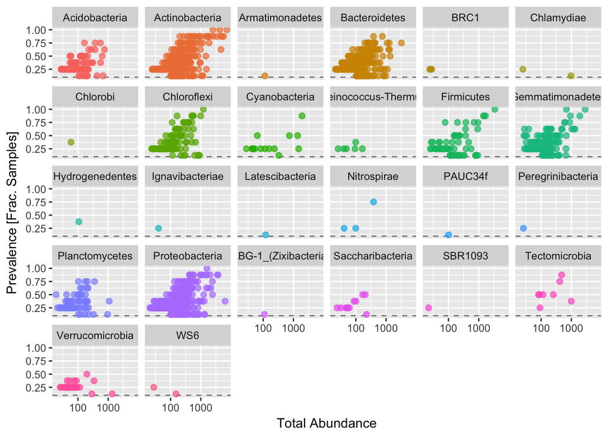

Figure S1.5.per-Phylum ASV prevalence

```r
plot_abundances(ps_filt)[[3]]
```

Final filtered sequences and variants per sample. There seems to be no correlation between number of sequences and number of variants:

```r
final_Sequences=sample_sums(ps_filt)
final_Variants=apply(ps_filt@otu_table,1,function(x){sum(x>0)})
data.frame(Final_seq=final_Sequences,Final_Variants=final_Variants)
```

```
##       Final_seq Final_Variants
## L1-1      40834            397
## L1-2a     95359            228
## L1-3a     47863            821
## L1-4      53218            876
## L2-1      58646            816
## L2-2      69135            763
## L2-3      44783            600
## L2-4      50745            775
```

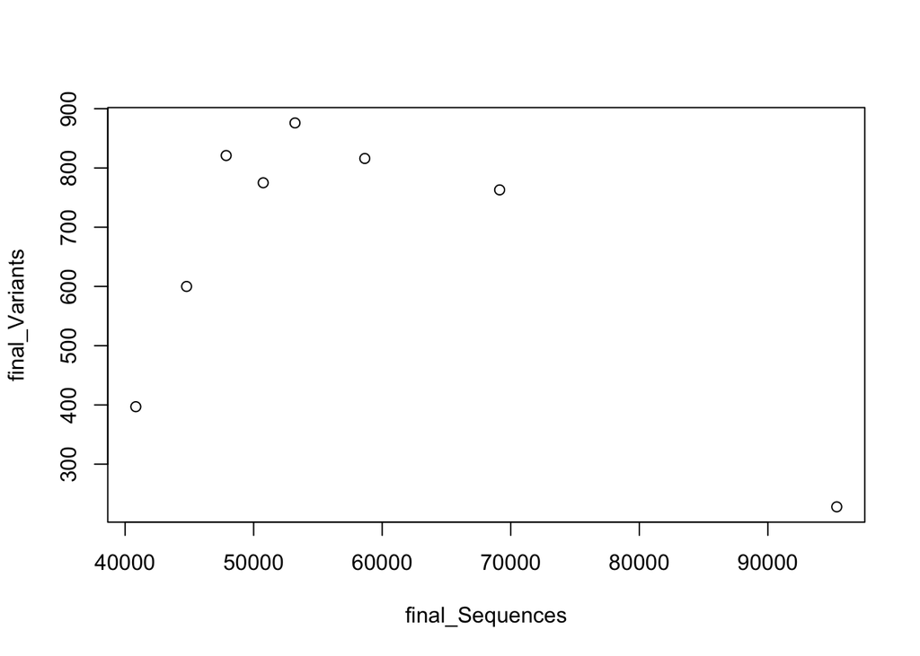

Figure S1.6.Correlation between number of variants and number of sequences

```r
plot(final_Sequences,final_Variants)
```

(Why not rarefy?: http://journals.plos.org/ploscompbiol/article?id=10.1371/journal.pcbi.1003531)

## 3. Analysis of diversity

### 3.1 Merge phylogenetic tree to phyloseq object

Export fasta from variants:

```r
seqs <- getSequences(otu_table(ps_filt)@.Data)
names(seqs) <- seqs # names variant  as its sequence

library(ShortRead)
writeFasta(DNAStringSet(seqs),"path_to/seq.fa")
```

Align-reconstruct tree iteratively with PASTA:

```bash
python run_pasta.py \
-i seq.fa \
-d dna \
--aligner=mafft \
--merger=OPAL \
--tree-estimator fasttree \
--num-cpus=2 \
--iter-limit=3 \
-j metarizo \
-o pasta_folder
# Note that the final alignment outputted by PASTA is NOT masked, but masked versions of the output are also saved as temporary files.
```

Open “tree.tre” in the text editor and remove lines 2 and 3. Import resulting tree from PASTA into phyloseq object:

```r
tree_metarizo<-phyloseq::read_tree("path_to_tree.tre")
tree_metarizo<-midpoint(tree_metarizo)#root tree
```

Merge phylogenetic tree to phyloseq object:

```r
ps_filt_t<-merge_phyloseq(ps_filt,tree_metarizo)
```

Add sample names:

```r
sample_names(ps_filt_t)<-c("jul1","jul2","jul3","jul4","oct1","oct2","oct3","oct4")
```

### 3.2 Estimate alfa diversity

```r
alpha_div<-estimate_richness(ps_filt_t,measures=c("Observed","Shannon"))
alpha_div<-data.frame(alpha_div,alpha_div$Shannon/log(alpha_div$Observed))
names(alpha_div)<-c("Observed","Shannon","Pielou")
alpha_div
```

```
##      Observed  Shannon    Pielou
## jul1      397 5.386705 0.9001942
## jul2      228 4.979067 0.9170657
## jul3      821 6.307221 0.9399001
## jul4      876 6.273532 0.9259325
## oct1      816 5.979114 0.8918174
## oct2      763 5.748111 0.8660371
## oct3      600 5.785695 0.9044487
## oct4      775 6.126482 0.9208791
```

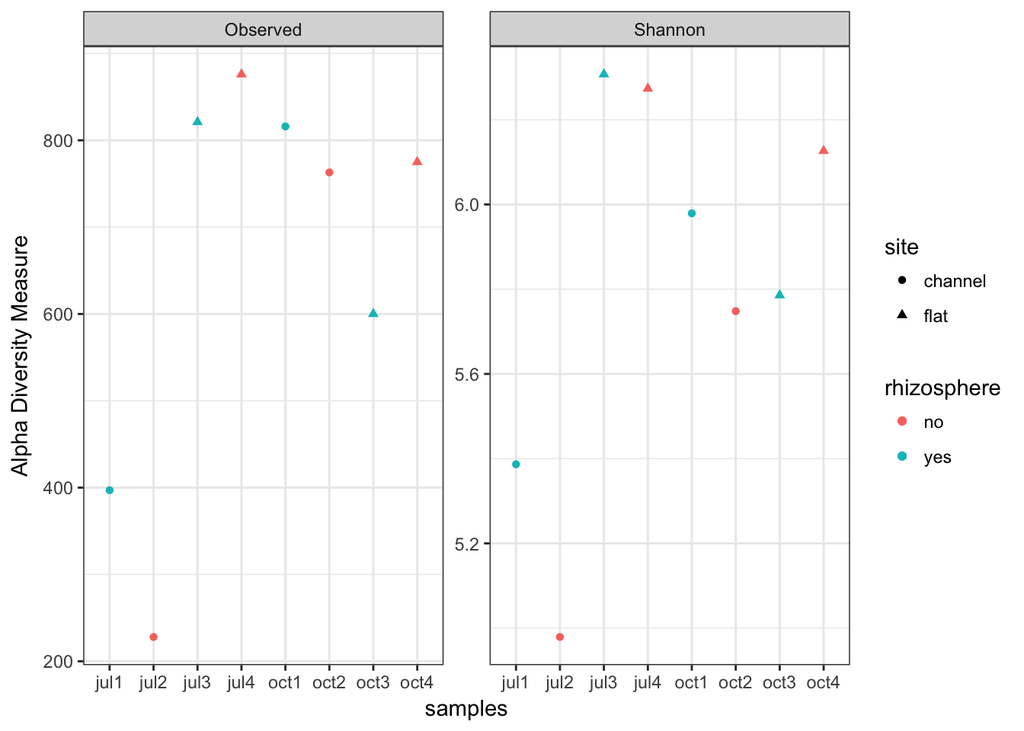

```r
plot_richness(ps_filt_t,x="sample", measures=c("Shannon", "Observed"), color="rhizosphere",shape="site") + theme_bw()
```

#### 3.2.1 Change of alpha diversity with agglomeration

We agglomerated variants using cophenetic distances from the tree to check how diversity changes with agglomeration and to detect potential overstimation of ASVs, which would be evident after shallow agglomeration.

```r
h=0
shannon_div<-data.frame(c(rep(NA,nsamples(ps_filt_t))))
observed_div<-data.frame(c(rep(NA,nsamples(ps_filt_t))))

glom0<-ps_filt_t
for (i in 1:8){
  assign(paste0("glom",i),tip_glom(get(paste0("glom",i-1)),h=h[i]))
  h[i+1]=0.05+h[i]
  shannon_div[,i]<-estimate_richness(get(paste0("glom",i)),measures=c("Shannon"))$Shannon
  observed_div[,i]<-estimate_richness(get(paste0("glom",i)),measures=c("Observed"))$Observed
  names(shannon_div)[i]<-paste0("glom",i,"_",h[i-1])
  names(observed_div)[i]<-paste0("glom",i,"_",h[i-1])
}
```

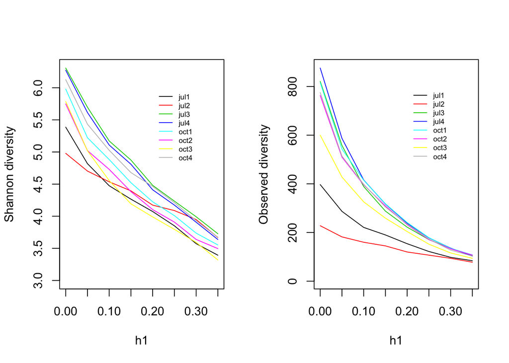

Figure S1.8. Change of alpha diversity with agglomeration (h1, tree distance)

```r
h1<-head(h,-1)
par(mfrow=c(1,2))
plot(h1,as.numeric(shannon_div[1,]),type="l",ylim = c(3,max(shannon_div)),ylab="Shannon diversity")
for (i in 2:8){
  lines(h1,shannon_div[i,],col=i)
}
legend(0.2,6,legend=sample_names(ps_filt_t),col=c(1:length(h1)),lty=1,bty="n",cex=0.6)

plot(h1,as.numeric(observed_div[1,]),type="l",ylim = c(3,max(observed_div)),ylab="Observed diversity")
for (i in 2:8){
  lines(h1,observed_div[i,],col=i)
}
legend(0.2,800,legend=sample_names(ps_filt_t),col=c(1:length(h1)),lty=1,bty="n",cex=0.6)
```

```r
par(mfrow=c(1,1))
```

#### 3.2.2 Create Qiime-like OTU tables

Transform abundance to relative values:

```r
ps_filt_tra = transform_sample_counts(ps_filt_t, function(x){x / sum(x)})
```

Create Qiime-like OTU tables for each taxonomic level:

```r
taxa_levels<-colnames(tax_table(ps_filt_tra)@.Data)[2:6]#names of taxonomic levels
Qotu_tables<-list()#empty list
library(xlsx)
write.xlsx("Qiime-like OTU tables", file="path_to/otu_tables.xlsx",row.names=F,col.names = F)#empty Excel file

for (i in 1:length(taxa_levels)){#loop
  ps3 = tax_glom(ps_filt_tra, taxa_levels[i], NArm = F)
OTUs<-t(otu_table(ps3)@.Data)
taxa<-tax_table(ps3)@.Data[,c(1:(1+i))]
level_tax<-assign(paste0("qiimeOTU_",taxa_levels[i]),cbind(taxa,OTUs))
Qotu_tables[[i]]<-level_tax
write.xlsx(level_tax,file="path_to/otu_tables.xlsx",sheetName=paste0(taxa_levels[i]),row.names=FALSE, append=TRUE)
}
```

Proportion of ASVs assigned to different taxonomic levels:

```r
total_taxa<-ntaxa(ps_filt_t)
nClass<-ntaxa(subset_taxa(ps_filt_t, !is.na(Class)))
nOrder<-ntaxa(subset_taxa(ps_filt_t, !is.na(Order)))
nFamily<-ntaxa(subset_taxa(ps_filt_t, !is.na(Family)))
nGenus<-ntaxa(subset_taxa(ps_filt_t, !is.na(Genus)))
data.frame("nClass"=nClass/total_taxa, "nOrder"=nOrder/total_taxa, "nFamily"=nFamily/total_taxa,"nGenus"= nGenus/total_taxa)
```

```
##      nClass    nOrder   nFamily    nGenus
## 1 0.9876543 0.8837449 0.7968107 0.4619342
```

#### 3.2.3 Most abundant phyla

Plot cumulative abundance per Phylum:

```r
#calculate culumative abundance per phylum
phylum_ps<-tax_glom(ps_filt_t, "Phylum")#agglomerate abundances per phylum
phylum_psm<-psmelt(phylum_ps)#melt ps
sum_phylum<-tapply(phylum_psm$Abundance,phylum_psm$Phylum,sum)/sum(phylum_psm$Abundance)#sum abundances per phylum
sum_phylum<-sort(sum_phylum)#sort
cum_sum_phylum<-cumsum(sum_phylum)#calculate cummulative sum

#calculate diversity per phylum
asv_phyla1<-table(tax_table(ps_filt_t)[, "Phylum"], exclude = NULL)#ASV per phylum
asv_phyla<-as.numeric(asv_phyla1)/sum(asv_phyla1)#sort and make relative
names(asv_phyla)<-names(asv_phyla1);rm(asv_phyla1)

cum_div_abun<-merge(data.frame("rel_ASV"=asv_phyla),data.frame(cum_sum_phylum),by=0,all=T)#combine diversity and abundance
cum_div_abun<-data.frame(cum_div_abun,row.names = 1)
cum_div_abun<-merge(cum_div_abun,data.frame("rel_abund"=sum_phylum),by=0,all=T)
cum_div_abun<-cum_div_abun[order(cum_div_abun[,3]),]#order by cumulative abundance
cum_div_abun<-cbind(cum_div_abun,"ASV"=cumsum(cum_div_abun$rel_ASV))
cum_div_abun<-data.frame(cum_div_abun,row.names = 1)
cum_div_abun
```

```
##                           rel_ASV cum_sum_phylum    rel_abund          ASV
## SBR1093              0.0005144033   4.776555e-05 4.776555e-05 0.0005144033
## Peregrinibacteria    0.0005144033   1.042157e-04 5.645019e-05 0.0010288066
## Ignavibacteriae      0.0005144033   1.910622e-04 8.684645e-05 0.0015432099
## Chlorobi             0.0005144033   3.191607e-04 1.280985e-04 0.0020576132
## BRC1                 0.0015432099   4.885113e-04 1.693506e-04 0.0036008230
## PAUC34f              0.0005144033   7.077986e-04 2.192873e-04 0.0041152263
## Hydrogenedentes      0.0005144033   9.401129e-04 2.323143e-04 0.0046296296
## RBG-1_(Zixibacteria) 0.0005144033   1.178941e-03 2.388277e-04 0.0051440329
## Armatimonadetes      0.0005144033   1.424282e-03 2.453412e-04 0.0056584362
## Latescibacteria      0.0005144033   1.684821e-03 2.605394e-04 0.0061728395
## WS6                  0.0010288066   2.073459e-03 3.886379e-04 0.0072016461
## Deinococcus-Thermus  0.0030864198   3.098247e-03 1.024788e-03 0.0102880658
## Nitrospirae          0.0015432099   4.235936e-03 1.137689e-03 0.0118312757
## Chlamydiae           0.0010288066   6.409268e-03 2.173332e-03 0.0128600823
## Saccharibacteria     0.0056584362   8.695501e-03 2.286233e-03 0.0185185185
## Tectomicrobia        0.0041152263   1.415380e-02 5.458300e-03 0.0226337449
## Verrucomicrobia      0.0128600823   2.166168e-02 7.507876e-03 0.0354938272
## Cyanobacteria        0.0082304527   3.632136e-02 1.465968e-02 0.0437242798
## Planctomycetes       0.0426954733   5.722096e-02 2.089960e-02 0.0864197531
## Acidobacteria        0.0447530864   8.502702e-02 2.780606e-02 0.1311728395
## Firmicutes           0.0360082305   1.354175e-01 5.039048e-02 0.1671810700
## Chloroflexi          0.0725308642   1.924344e-01 5.701687e-02 0.2397119342
## Gemmatimonadetes     0.0843621399   2.668314e-01 7.439701e-02 0.3240740741
## Bacteroidetes        0.1471193416   3.899254e-01 1.230940e-01 0.4711934156
## Actinobacteria       0.2042181070   6.760063e-01 2.860809e-01 0.6754115226
## Proteobacteria       0.3245884774   1.000000e+00 3.239937e-01 1.0000000000
```

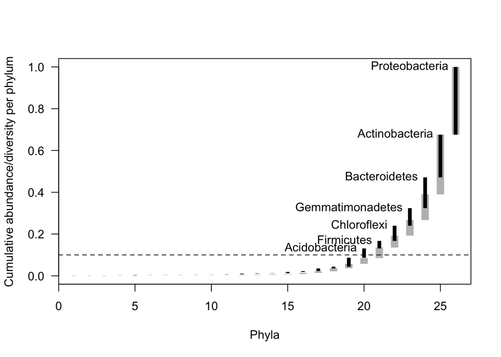

Figure S1.9. Most dominant/diverse phyla

```r
#plot cumulative abundance/diversity
plot(cum_div_abun$cum_sum_phylum,type="n",ylab="Cumulative abundance/diversity per phylum",xlab="Phyla",yaxt="n")#Plot
axis(2, las=2)
segments(c(1:length(cum_div_abun$cum_sum_phylum)),c(0,head(cum_div_abun$cum_sum_phylum,-1)),c(1:length(cum_div_abun$cum_sum_phylum)),cum_div_abun$cum_sum_phylum,lwd=10,col = "grey" ,lend=1)#add phyla
abline(h=0.1,lty=2)#0.1 line
text(c(20:26),cum_div_abun$ASV[20:26],rownames(cum_div_abun)[20:26],pos=2)#phyla names

segments(c(1:length(cum_div_abun$ASV)),c(0,head(cum_div_abun$ASV,-1)),c(1:length(cum_div_abun$ASV)),cum_div_abun$ASV,lwd=5,col = 1,lend=1)#overplot
```

### 3.2 Estimate beta diversity

Transformation of the abundances to natural logarithmic scale:

```r
ps_filt_tlog <- transform_sample_counts(ps_filt_t, function(x) log(1 + x))
```

MDS with weighted UNIFRAC distances:

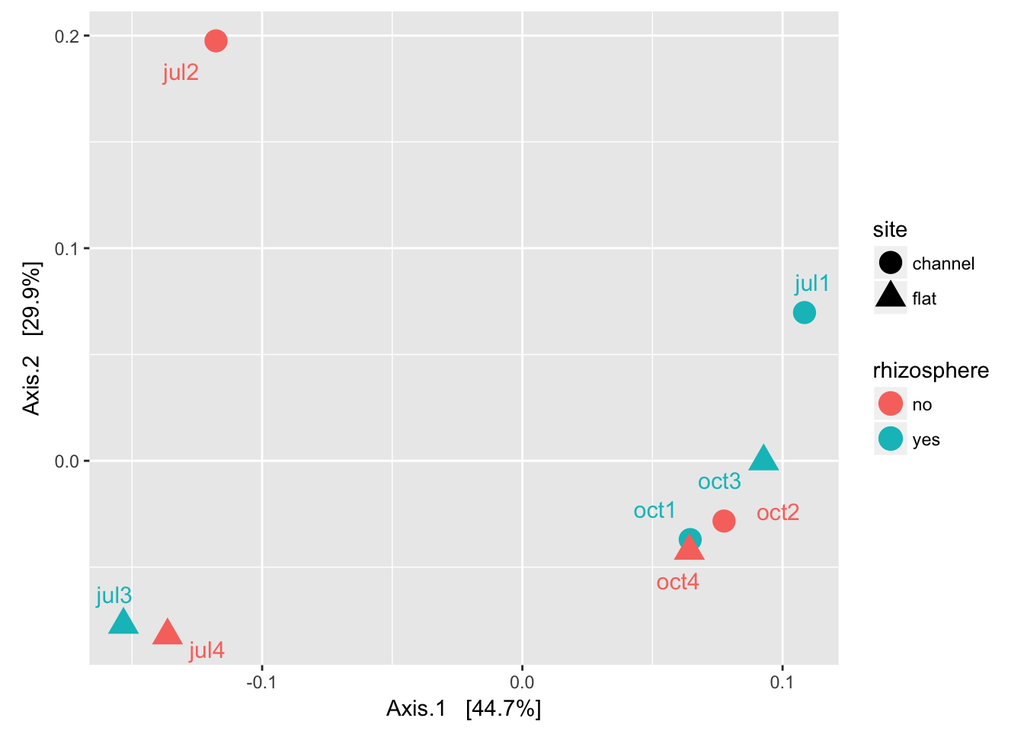

Figure S1.10. Beta diversity: MDS from weighted UNIFRAC distances

```r
unif_meta <- ordinate(ps_filt_tlog, method = "MDS", distance = "wunifrac")
evals <- unif_meta$values$Eigenvalues
library("ggrepel")#has function to "repel" overlaping labels in plot
plot_ordination(ps_filt_tlog, unif_meta,axes = c(1,2),shape="site", color = "rhizosphere") +
  labs("site","rhizosphere") +
  geom_point(size=5)+
  coord_fixed(sqrt(evals[2] / evals[1]))+
  geom_text_repel(aes(label=sample_names(ps_filt_tlog)),size=4,min.segment.length=1,point.padding=0.5)
```

```r
unif_meta$values
```

```
##    Eigenvalues Relative_eig Broken_stick Cumul_eig Cumul_br_stick
## 1 0.0905933881  0.447274241   0.37040816 0.4472742      0.3704082
## 2 0.0605405208  0.298898364   0.22755102 0.7461726      0.5979592
## 3 0.0285431246  0.140922033   0.15612245 0.8870946      0.7540816
## 4 0.0156000821  0.077020134   0.10850340 0.9641148      0.8625850
## 5 0.0042432941  0.020949831   0.07278912 0.9850646      0.9353741
## 6 0.0021895123  0.010809977   0.04421769 0.9958746      0.9795918
## 7 0.0008355855  0.004125421   0.02040816 1.0000000      1.0000000
```

Exploration of other dimensions. The scaling of y axis is proportional to the variance explained:

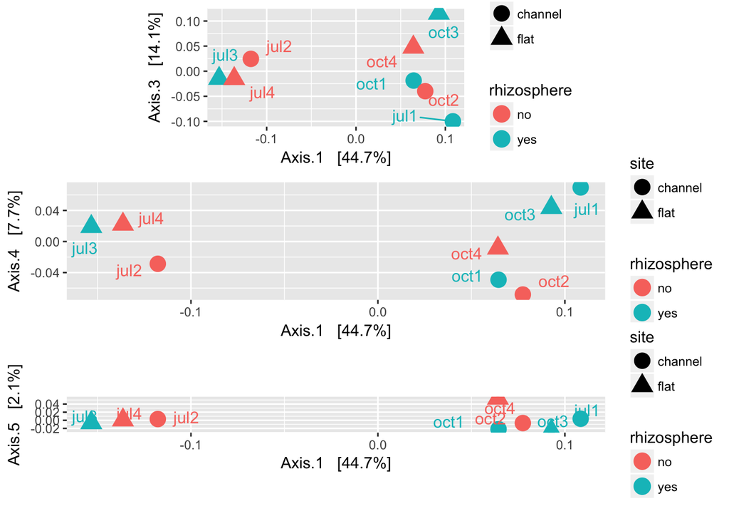

Figure S1.11. Beta diversity: MDS from weighted UNIFRAC distances for dimensions 3 to 5

```r
for (i in 3:5){
  assign(paste0("plot",i),
  plot_ordination(ps_filt_tlog, unif_meta,axes = c(1,i),shape="site", color = "rhizosphere") +
  labs("site","rhizosphere") +
  geom_point(size=5)+
  coord_fixed(sqrt(evals[i] / evals[1]))+
  geom_text_repel(aes(label=sample_names(ps_filt_tlog)),size=4,min.segment.length=1,point.padding=0.5))
}
library(grid)
library(gridExtra)
grid.arrange(plot3,plot4,plot5)
```